# Risk Factor Analysis

## Outcome Variable

**Outcome Variable:** ever_sstunted

## Predictor Variables

**Intervention Variable:** brthmon

**Adjustment Set:**

unadjusted

## Stratifying Variables

The analysis was stratified on these variable(s):

- agecat
- studyid
- country

## Data Summary

| agecat | studyid | country | brthmon | ever_sstunted | n_cell | n |
| --- | --- | --- | --- | --- | --- | --- |
| 0-24 months | CMC-V-BCS-2002 | INDIA | 1 | 0 | 14 | 373 |
| 0-24 months | CMC-V-BCS-2002 | INDIA | 1 | 1 | 20 | 373 |
| 0-24 months | CMC-V-BCS-2002 | INDIA | 2 | 0 | 4 | 373 |
| 0-24 months | CMC-V-BCS-2002 | INDIA | 2 | 1 | 12 | 373 |
| 0-24 months | CMC-V-BCS-2002 | INDIA | 3 | 0 | 11 | 373 |
| 0-24 months | CMC-V-BCS-2002 | INDIA | 3 | 1 | 20 | 373 |
| 0-24 months | CMC-V-BCS-2002 | INDIA | 4 | 0 | 22 | 373 |
| 0-24 months | CMC-V-BCS-2002 | INDIA | 4 | 1 | 22 | 373 |
| 0-24 months | CMC-V-BCS-2002 | INDIA | 5 | 0 | 14 | 373 |
| 0-24 months | CMC-V-BCS-2002 | INDIA | 5 | 1 | 22 | 373 |
| 0-24 months | CMC-V-BCS-2002 | INDIA | 6 | 0 | 15 | 373 |
| 0-24 months | CMC-V-BCS-2002 | INDIA | 6 | 1 | 22 | 373 |
| 0-24 months | CMC-V-BCS-2002 | INDIA | 7 | 0 | 13 | 373 |
| 0-24 months | CMC-V-BCS-2002 | INDIA | 7 | 1 | 26 | 373 |
| 0-24 months | CMC-V-BCS-2002 | INDIA | 8 | 0 | 6 | 373 |
| 0-24 months | CMC-V-BCS-2002 | INDIA | 8 | 1 | 12 | 373 |
| 0-24 months | CMC-V-BCS-2002 | INDIA | 9 | 0 | 7 | 373 |
| 0-24 months | CMC-V-BCS-2002 | INDIA | 9 | 1 | 14 | 373 |
| 0-24 months | CMC-V-BCS-2002 | INDIA | 10 | 0 | 11 | 373 |
| 0-24 months | CMC-V-BCS-2002 | INDIA | 10 | 1 | 18 | 373 |
| 0-24 months | CMC-V-BCS-2002 | INDIA | 11 | 0 | 15 | 373 |
| 0-24 months | CMC-V-BCS-2002 | INDIA | 11 | 1 | 28 | 373 |
| 0-24 months | CMC-V-BCS-2002 | INDIA | 12 | 0 | 4 | 373 |
| 0-24 months | CMC-V-BCS-2002 | INDIA | 12 | 1 | 21 | 373 |
| 0-24 months | CMIN | BANGLADESH | 1 | 0 | 14 | 277 |
| 0-24 months | CMIN | BANGLADESH | 1 | 1 | 16 | 277 |
| 0-24 months | CMIN | BANGLADESH | 2 | 0 | 19 | 277 |
| 0-24 months | CMIN | BANGLADESH | 2 | 1 | 8 | 277 |
| 0-24 months | CMIN | BANGLADESH | 3 | 0 | 12 | 277 |
| 0-24 months | CMIN | BANGLADESH | 3 | 1 | 8 | 277 |

[output cut: 618 more lines]

The following strata were considered:

- agecat: 0-24 months, studyid: CMC-V-BCS-2002, country: INDIA
- agecat: 0-24 months, studyid: CMIN, country: BANGLADESH
- agecat: 0-24 months, studyid: CONTENT, country: PERU
- agecat: 0-24 months, studyid: EE, country: PAKISTAN
- agecat: 0-24 months, studyid: GMS-Nepal, country: NEPAL
- agecat: 0-24 months, studyid: Guatemala BSC, country: GUATEMALA
- agecat: 0-24 months, studyid: iLiNS-Zinc, country: BURKINA FASO
- agecat: 0-24 months, studyid: IRC, country: INDIA
- agecat: 0-24 months, studyid: JiVitA-3, country: BANGLADESH
- agecat: 0-24 months, studyid: JiVitA-4, country: BANGLADESH
- agecat: 0-24 months, studyid: Keneba, country: GAMBIA
- agecat: 0-24 months, studyid: LCNI-5, country: MALAWI
- agecat: 0-24 months, studyid: MAL-ED, country: BANGLADESH
- agecat: 0-24 months, studyid: MAL-ED, country: BRAZIL
- agecat: 0-24 months, studyid: MAL-ED, country: INDIA
- agecat: 0-24 months, studyid: MAL-ED, country: NEPAL
- agecat: 0-24 months, studyid: MAL-ED, country: PERU
- agecat: 0-24 months, studyid: MAL-ED, country: SOUTH AFRICA
- agecat: 0-24 months, studyid: MAL-ED, country: TANZANIA, UNITED REPUBLIC OF
- agecat: 0-24 months, studyid: NIH-Birth, country: BANGLADESH
- agecat: 0-24 months, studyid: PROBIT, country: BELARUS
- agecat: 0-24 months, studyid: PROVIDE, country: BANGLADESH
- agecat: 0-24 months, studyid: ResPak, country: PAKISTAN
- agecat: 0-24 months, studyid: SAS-CompFeed, country: INDIA
- agecat: 0-24 months, studyid: SAS-FoodSuppl, country: INDIA
- agecat: 0-24 months, studyid: TanzaniaChild2, country: TANZANIA, UNITED REPUBLIC OF
- agecat: 0-24 months, studyid: ZVITAMBO, country: ZIMBABWE

### Dropped Strata

Some strata were dropped due to rare outcomes:

- agecat: 0-24 months, studyid: CMC-V-BCS-2002, country: INDIA
- agecat: 0-24 months, studyid: CMIN, country: BANGLADESH
- agecat: 0-24 months, studyid: CONTENT, country: PERU
- agecat: 0-24 months, studyid: EE, country: PAKISTAN
- agecat: 0-24 months, studyid: GMS-Nepal, country: NEPAL
- agecat: 0-24 months, studyid: Guatemala BSC, country: GUATEMALA
- agecat: 0-24 months, studyid: JiVitA-4, country: BANGLADESH
- agecat: 0-24 months, studyid: LCNI-5, country: MALAWI
- agecat: 0-24 months, studyid: MAL-ED, country: BANGLADESH
- agecat: 0-24 months, studyid: MAL-ED, country: BRAZIL
- agecat: 0-24 months, studyid: MAL-ED, country: INDIA
- agecat: 0-24 months, studyid: MAL-ED, country: NEPAL
- agecat: 0-24 months, studyid: MAL-ED, country: PERU
- agecat: 0-24 months, studyid: MAL-ED, country: SOUTH AFRICA
- agecat: 0-24 months, studyid: MAL-ED, country: TANZANIA, UNITED REPUBLIC OF
- agecat: 0-24 months, studyid: PROVIDE, country: BANGLADESH
- agecat: 0-24 months, studyid: ResPak, country: PAKISTAN
- agecat: 0-24 months, studyid: SAS-FoodSuppl, country: INDIA

## Methods Detail

We're interested in the causal parameters $E[Y_a]$ for all values of $a \in \mathcal{A}$. These parameters represent the mean outcome if, possibly contrary to fact, we intervened to set all units to have $A=a$. Under the randomization and positivity assumptions, these are identified by the statistical parameters $\psi_a=E_W[E_{Y|A,W}(Y|A=a,W)]$. In addition, we're interested in the mean of $Y$, $E[Y]$ under no intervention (the observed mean). We will estimate these parameters by using SuperLearner to fit the relevant likelihood factors -- $E_{Y|A,W}(Y|A=a,W)$ and $p(A=a|W)$, and then updating our likelihood fit using a joint TMLE.

For unadjusted analyses ($W=\{\}$), initial likelihoods were estimated using Lrnr_glm to estimate the simple $E(Y|A)$ and Lrnr_mean to estimate $p(A)$. For adjusted analyses, a small library containing Lrnr_glmnet, Lrnr_xgboost, and Lrnr_mean was used.

Having estimated these parameters, we will then use the delta method to estimate relative risks and attributable risks relative to a prespecified baseline level of $A$.

# Results Detail

## Results Plots

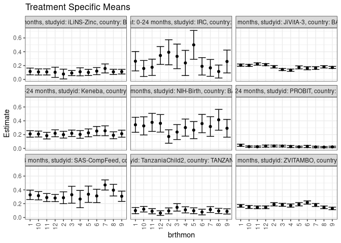

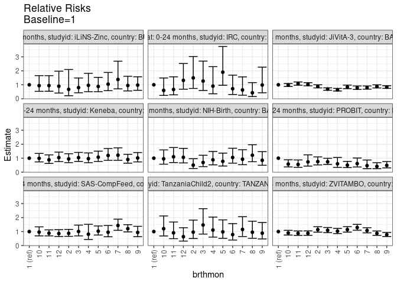

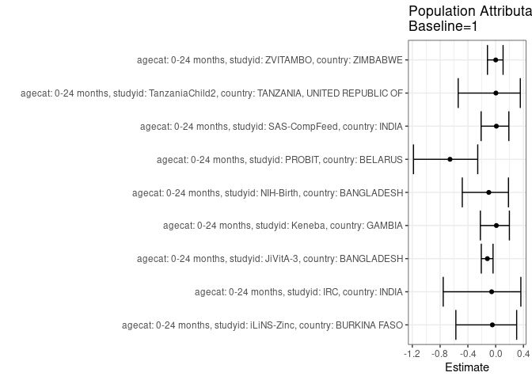

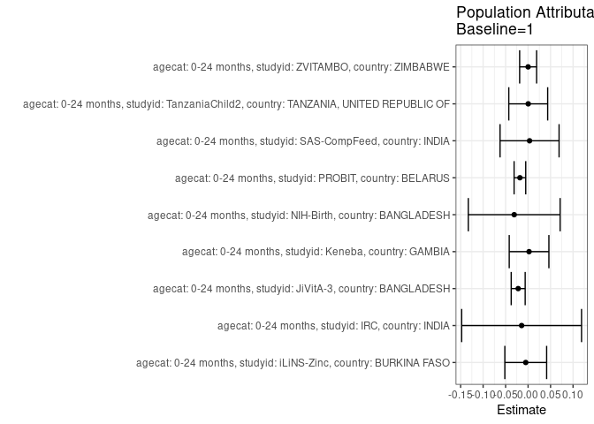

## Results Table

### Parameter: TSM

| agecat | studyid | country | intervention_level | baseline_level | estimate | ci_lower | ci_upper |
| --- | --- | --- | --- | --- | --- | --- | --- |
| 0-24 months | iLiNS-Zinc | BURKINA FASO | 1 | NA | 0.1145511 | 0.0656331 | 0.1634691 |
| 0-24 months | iLiNS-Zinc | BURKINA FASO | 2 | NA | 0.0773481 | 0.0065816 | 0.1481146 |
| 0-24 months | iLiNS-Zinc | BURKINA FASO | 3 | NA | 0.0913706 | 0.0543252 | 0.1284160 |
| 0-24 months | iLiNS-Zinc | BURKINA FASO | 4 | NA | 0.1100478 | 0.0520423 | 0.1680534 |
| 0-24 months | iLiNS-Zinc | BURKINA FASO | 5 | NA | 0.1009174 | 0.0566853 | 0.1451496 |
| 0-24 months | iLiNS-Zinc | BURKINA FASO | 6 | NA | 0.1197917 | 0.0683115 | 0.1712718 |
| 0-24 months | iLiNS-Zinc | BURKINA FASO | 7 | NA | 0.1581633 | 0.0933138 | 0.2230127 |
| 0-24 months | iLiNS-Zinc | BURKINA FASO | 8 | NA | 0.1089109 | 0.0706911 | 0.1471307 |
| 0-24 months | iLiNS-Zinc | BURKINA FASO | 9 | NA | 0.1119221 | 0.0777494 | 0.1460949 |
| 0-24 months | iLiNS-Zinc | BURKINA FASO | 10 | NA | 0.1075269 | 0.0634422 | 0.1516116 |
| 0-24 months | iLiNS-Zinc | BURKINA FASO | 11 | NA | 0.1081871 | 0.0640286 | 0.1523457 |
| 0-24 months | iLiNS-Zinc | BURKINA FASO | 12 | NA | 0.1028037 | 0.0287486 | 0.1768588 |
| 0-24 months | IRC | INDIA | 1 | NA | 0.2631579 | 0.1229792 | 0.4033366 |
| 0-24 months | IRC | INDIA | 2 | NA | 0.3928571 | 0.2117389 | 0.5739754 |
| 0-24 months | IRC | INDIA | 3 | NA | 0.3333333 | 0.1553045 | 0.5113621 |
| 0-24 months | IRC | INDIA | 4 | NA | 0.2380952 | 0.0557080 | 0.4204825 |
| 0-24 months | IRC | INDIA | 5 | NA | 0.5000000 | 0.2908119 | 0.7091881 |
| 0-24 months | IRC | INDIA | 6 | NA | 0.1891892 | 0.0628362 | 0.3155422 |
| 0-24 months | IRC | INDIA | 7 | NA | 0.1666667 | 0.0447787 | 0.2885546 |
| 0-24 months | IRC | INDIA | 8 | NA | 0.1136364 | 0.0197469 | 0.2075258 |
| 0-24 months | IRC | INDIA | 9 | NA | 0.2592593 | 0.0937597 | 0.4247588 |
| 0-24 months | IRC | INDIA | 10 | NA | 0.1578947 | 0.0418158 | 0.2739737 |
| 0-24 months | IRC | INDIA | 11 | NA | 0.1750000 | 0.0571053 | 0.2928947 |
| 0-24 months | IRC | INDIA | 12 | NA | 0.3461538 | 0.2166898 | 0.4756179 |
| 0-24 months | JiVitA-3 | BANGLADESH | 1 | NA | 0.2064618 | 0.1901470 | 0.2227765 |
| 0-24 months | JiVitA-3 | BANGLADESH | 2 | NA | 0.1822136 | 0.1642505 | 0.2001768 |
| 0-24 months | JiVitA-3 | BANGLADESH | 3 | NA | 0.1426223 | 0.1275887 | 0.1576558 |
| 0-24 months | JiVitA-3 | BANGLADESH | 4 | NA | 0.1328829 | 0.1164758 | 0.1492900 |
| 0-24 months | JiVitA-3 | BANGLADESH | 5 | NA | 0.1735849 | 0.1517936 | 0.1953762 |
| 0-24 months | JiVitA-3 | BANGLADESH | 6 | NA | 0.1613133 | 0.1393212 | 0.1833055 |

[output cut: 78 more lines]

### Parameter: E(Y)

| agecat | studyid | country | intervention_level | baseline_level | estimate | ci_lower | ci_upper |
| --- | --- | --- | --- | --- | --- | --- | --- |
| 0-24 months | iLiNS-Zinc | BURKINA FASO | NA | NA | 0.1093415 | 0.0900773 | 0.1286057 |
| 0-24 months | IRC | INDIA | NA | NA | 0.2487805 | 0.2068840 | 0.2906770 |
| 0-24 months | JiVitA-3 | BANGLADESH | NA | NA | 0.1844493 | 0.1788538 | 0.1900447 |
| 0-24 months | Keneba | GAMBIA | NA | NA | 0.2123499 | 0.1975010 | 0.2271989 |
| 0-24 months | NIH-Birth | BANGLADESH | NA | NA | 0.3116057 | 0.2753823 | 0.3478292 |
| 0-24 months | PROBIT | BELARUS | NA | NA | 0.0276380 | 0.0201988 | 0.0350773 |
| 0-24 months | SAS-CompFeed | INDIA | NA | NA | 0.3307241 | 0.3024794 | 0.3589688 |
| 0-24 months | TanzaniaChild2 | TANZANIA, UNITED REPUBLIC OF | NA | NA | 0.0997496 | 0.0877482 | 0.1117510 |
| 0-24 months | ZVITAMBO | ZIMBABWE | NA | NA | 0.1681114 | 0.1619329 | 0.1742900 |

### Parameter: RR

| agecat | studyid | country | intervention_level | baseline_level | estimate | ci_lower | ci_upper |
| --- | --- | --- | --- | --- | --- | --- | --- |
| 0-24 months | iLiNS-Zinc | BURKINA FASO | 1 | 1 | 1.0000000 | 1.0000000 | 1.0000000 |
| 0-24 months | iLiNS-Zinc | BURKINA FASO | 2 | 1 | 0.6752277 | 0.2177221 | 2.0941028 |
| 0-24 months | iLiNS-Zinc | BURKINA FASO | 3 | 1 | 0.7976403 | 0.4284328 | 1.4850171 |
| 0-24 months | iLiNS-Zinc | BURKINA FASO | 4 | 1 | 0.9606880 | 0.5072730 | 1.8193781 |
| 0-24 months | iLiNS-Zinc | BURKINA FASO | 5 | 1 | 0.8809819 | 0.5070830 | 1.5305760 |
| 0-24 months | iLiNS-Zinc | BURKINA FASO | 6 | 1 | 1.0457489 | 0.5808310 | 1.8828037 |
| 0-24 months | iLiNS-Zinc | BURKINA FASO | 7 | 1 | 1.3807226 | 0.7093261 | 2.6876139 |
| 0-24 months | iLiNS-Zinc | BURKINA FASO | 8 | 1 | 0.9507626 | 0.5617538 | 1.6091563 |
| 0-24 months | iLiNS-Zinc | BURKINA FASO | 9 | 1 | 0.9770500 | 0.6068383 | 1.5731155 |
| 0-24 months | iLiNS-Zinc | BURKINA FASO | 10 | 1 | 0.9386806 | 0.5327073 | 1.6540438 |
| 0-24 months | iLiNS-Zinc | BURKINA FASO | 11 | 1 | 0.9444444 | 0.5396290 | 1.6529416 |
| 0-24 months | iLiNS-Zinc | BURKINA FASO | 12 | 1 | 0.8974489 | 0.4079217 | 1.9744341 |
| 0-24 months | IRC | INDIA | 1 | 1 | 1.0000000 | 1.0000000 | 1.0000000 |
| 0-24 months | IRC | INDIA | 2 | 1 | 1.4928571 | 0.7380162 | 3.0197472 |
| 0-24 months | IRC | INDIA | 3 | 1 | 1.2666667 | 0.5957531 | 2.6931364 |
| 0-24 months | IRC | INDIA | 4 | 1 | 0.9047619 | 0.3558975 | 2.3000840 |
| 0-24 months | IRC | INDIA | 5 | 1 | 1.9000000 | 0.9651389 | 3.7403943 |
| 0-24 months | IRC | INDIA | 6 | 1 | 0.7189189 | 0.3059649 | 1.6892280 |
| 0-24 months | IRC | INDIA | 7 | 1 | 0.6333333 | 0.2562718 | 1.5651783 |
| 0-24 months | IRC | INDIA | 8 | 1 | 0.4318182 | 0.1615717 | 1.1540814 |
| 0-24 months | IRC | INDIA | 9 | 1 | 0.9851852 | 0.4289835 | 2.2625340 |
| 0-24 months | IRC | INDIA | 10 | 1 | 0.6000000 | 0.2420309 | 1.4874132 |
| 0-24 months | IRC | INDIA | 11 | 1 | 0.6650000 | 0.2817309 | 1.5696718 |
| 0-24 months | IRC | INDIA | 12 | 1 | 1.3153846 | 0.6860957 | 2.5218593 |
| 0-24 months | JiVitA-3 | BANGLADESH | 1 | 1 | 1.0000000 | 1.0000000 | 1.0000000 |
| 0-24 months | JiVitA-3 | BANGLADESH | 2 | 1 | 0.8825538 | 0.7778993 | 1.0012880 |
| 0-24 months | JiVitA-3 | BANGLADESH | 3 | 1 | 0.6907926 | 0.6094217 | 0.7830283 |
| 0-24 months | JiVitA-3 | BANGLADESH | 4 | 1 | 0.6436198 | 0.5566282 | 0.7442067 |
| 0-24 months | JiVitA-3 | BANGLADESH | 5 | 1 | 0.8407605 | 0.7225505 | 0.9783097 |
| 0-24 months | JiVitA-3 | BANGLADESH | 6 | 1 | 0.7813230 | 0.6670022 | 0.9152379 |

[output cut: 78 more lines]

### Parameter: PAR

| agecat | studyid | country | intervention_level | baseline_level | estimate | ci_lower | ci_upper |
| --- | --- | --- | --- | --- | --- | --- | --- |
| 0-24 months | iLiNS-Zinc | BURKINA FASO | 1 | NA | -0.0052096 | -0.0517005 | 0.0412813 |
| 0-24 months | IRC | INDIA | 1 | NA | -0.0143774 | -0.1476551 | 0.1189002 |
| 0-24 months | JiVitA-3 | BANGLADESH | 1 | NA | -0.0220125 | -0.0375469 | -0.0064781 |
| 0-24 months | Keneba | GAMBIA | 1 | NA | 0.0021804 | -0.0419238 | 0.0462846 |
| 0-24 months | NIH-Birth | BANGLADESH | 1 | NA | -0.0308600 | -0.1329672 | 0.0712471 |
| 0-24 months | PROBIT | BELARUS | 1 | NA | -0.0181709 | -0.0311026 | -0.0052392 |
| 0-24 months | SAS-CompFeed | INDIA | 1 | NA | 0.0032904 | -0.0623284 | 0.0689093 |
| 0-24 months | TanzaniaChild2 | TANZANIA, UNITED REPUBLIC OF | 1 | NA | 0.0003344 | -0.0428972 | 0.0435659 |
| 0-24 months | ZVITAMBO | ZIMBABWE | 1 | NA | 0.0000997 | -0.0187644 | 0.0189638 |

### Parameter: PAF

| agecat | studyid | country | intervention_level | baseline_level | estimate | ci_lower | ci_upper |
| --- | --- | --- | --- | --- | --- | --- | --- |
| 0-24 months | iLiNS-Zinc | BURKINA FASO | 1 | NA | -0.0476451 | -0.5731823 | 0.3023312 |
| 0-24 months | IRC | INDIA | 1 | NA | -0.0577915 | -0.7552536 | 0.3625292 |
| 0-24 months | JiVitA-3 | BANGLADESH | 1 | NA | -0.1193419 | -0.2070404 | -0.0380152 |
| 0-24 months | Keneba | GAMBIA | 1 | NA | 0.0102681 | -0.2208276 | 0.1976186 |
| 0-24 months | NIH-Birth | BANGLADESH | 1 | NA | -0.0990355 | -0.4808036 | 0.1843084 |
| 0-24 months | PROBIT | BELARUS | 1 | NA | -0.6574606 | -1.1832032 | -0.2583234 |
| 0-24 months | SAS-CompFeed | INDIA | 1 | NA | 0.0099492 | -0.2096216 | 0.1896635 |
| 0-24 months | TanzaniaChild2 | TANZANIA, UNITED REPUBLIC OF | 1 | NA | 0.0033522 | -0.5395662 | 0.3548138 |
| 0-24 months | ZVITAMBO | ZIMBABWE | 1 | NA | 0.0005929 | -0.1181610 | 0.1067346 |